# Recruitment and Selection Analytics

Groupwork Use Case 5 - People Analytics

Ferrán Extremera, Irene Morales, Amalia Varo y Martina Iscar

2026-04-28

# Intro

In this final workshop, you will apply analytics techniques to recruitment and selection data to identify potential biases, evaluate the fairness of selection decisions, and assess whether assessment centre data can predict performance and turnover. You will use chi-square tests, logistic and linear regression models to uncover hidden patterns and build evidence-based recommendations.

# Setup

Within the project directory, create the following folders if they do not already exist:

- **Databases**: to store all data sources provided in Moodle (Excel files).
- **data**: to store any ad-hoc data created during the analysis. The native R data format is .rds.
- **report**: to store the HTML output file generated when knitting the R Markdown file.

# Prompt 1: Exploring Diversity in the Applicant Pool

### Tasks

- Import ‘recruitment_applicants_2023.xlsx’ into R (definitions of all fields are included in the ‘variable key’ worksheet within the Excel file).
- Recode gender and UG variables.
- Generate frequency tables for Gender, UG, Shortlisted, Interviewed, Offered, Accepted, Joined.
- Interpret patterns in diversity at each recruitment stage.

### Deliverables

- Table of frequencies.
- Initial diagnosis: Where in the pipeline are UG or female applicants being lost?

## Solution

### Table of frequencies

```r
# Load libraries
library(readxl)
library(dplyr)
library(janitor)
# Import dataset
df1 <- read_excel("Databases/recruitment_applicants_2023.xlsx")

# Clean names
df1 <- clean_names(df1)

# Check names
names(df1)
```

```
## [1] "applicant_code"  "gender"          "u_gyn"           "shortlisted_ny"
## [5] "interviewed"     "female_o_npanel" "offer_ny"        "accept_ny"
## [9] "join_yn"
```

```r
names(df1)
```

```
## [1] "applicant_code"  "gender"          "u_gyn"           "shortlisted_ny"
## [5] "interviewed"     "female_o_npanel" "offer_ny"        "accept_ny"
## [9] "join_yn"
```

```r
glimpse(df1)
```

```
## Rows: 280
## Columns: 9
## $ applicant_code  <dbl> 1, 2, 3, 4, 5, 6, 7, 8, 9, 10, 11, 12, 13, 14, 15, 16,…
## $ gender          <dbl> 1, 1, 1, 1, 1, 1, 1, 1, 1, 1, 1, 1, 1, 1, 1, 1, 1, 1, …
## $ u_gyn           <dbl> 2, 2, 2, 2, 2, 2, 2, 2, 1, 2, 2, 2, 2, 2, 2, 2, 1, 1, …
## $ shortlisted_ny  <dbl> 1, 1, 1, 1, 1, 1, 1, 1, 1, 1, 1, 1, 1, 1, 1, 1, 1, 1, …
## $ interviewed     <dbl> 1, 1, 1, 1, 1, 1, 1, 1, 1, 0, 0, 0, 0, 0, 0, 0, 0, 0, …
## $ female_o_npanel <dbl> 1, 1, 1, 2, 2, 2, 2, 1, 1, NA, NA, NA, NA, NA, NA, NA,…
## $ offer_ny        <dbl> 1, 1, 1, 1, 0, 0, 0, 0, 0, NA, NA, NA, NA, NA, NA, NA,…
## $ accept_ny       <dbl> 1, 1, 1, 1, NA, NA, NA, NA, NA, NA, NA, NA, NA, NA, NA…
## $ join_yn         <dbl> 1, 1, 1, 1, NA, NA, NA, NA, NA, NA, NA, NA, NA, NA, NA…
```

```r
# Recode variables
# Recode variables
df1 <- df1 %>%
  mutate(
    gender_rec = case_when(
      gender %in% c(1, "1", "F", "Female") ~ "Female",
      gender %in% c(2, "2", "M", "Male") ~ "Male",
      TRUE ~ "Other/Unknown"
    ),
    ug_rec = case_when(
      u_gyn %in% c(1, "1", "Y", "Yes") ~ "UG",
      u_gyn %in% c(2, "2", "N", "No") ~ "Non-UG",
      TRUE ~ "Unknown"
    )
  )

# Frequency tables
freq_gender <- tabyl(df1$gender_rec)
freq_ug <- tabyl(df1$ug_rec)
freq_shortlisted <- tabyl(df1$shortlisted_ny)
freq_interviewed <- tabyl(df1$interviewed)
freq_offered <- tabyl(df1$offer_ny)
freq_accepted <- tabyl(df1$accept_ny)
freq_joined <- tabyl(df1$join_yn)

freq_gender
```

```
##  df1$gender_rec   n   percent
##          Female  78 0.2785714
##            Male 202 0.7214286
```

```r
freq_ug
```

```
##  df1$ug_rec   n   percent
##      Non-UG 159 0.5678571
##          UG 121 0.4321429
```

```r
freq_shortlisted
```

```
##  df1$shortlisted_ny   n   percent
##                   0 192 0.6857143
##                   1  88 0.3142857
```

```r
freq_interviewed
```

```
##  df1$interviewed   n   percent
##                0 225 0.8035714
##                1  55 0.1964286
```

```r
freq_offered
```

```
##  df1$offer_ny   n    percent valid_percent
##             0  27 0.09642857     0.4909091
##             1  28 0.10000000     0.5090909
##            NA 225 0.80357143            NA
```

```r
freq_accepted
```

```
##  df1$accept_ny   n    percent valid_percent
##              0  10 0.03571429     0.3571429
##              1  18 0.06428571     0.6428571
##             NA 252 0.90000000            NA
```

```r
freq_joined
```

```
##  df1$join_yn   n    percent valid_percent
##            0  10 0.03571429     0.3571429
##            1  18 0.06428571     0.6428571
##           NA 252 0.90000000            NA
```

```r
# Print results
```

The results provide a clear overview of how the recruitment process operates and where the main issues may lie.

Looking at the progression through the recruitment stages, the data shows a strong filtering effect in the early phases. Only about 31% of applicants are shortlisted, and less than 20% reach the interview stage. This indicates that the majority of candidates are eliminated very early in the process. However, once candidates reach the interview stage, the process becomes more selective but also more efficient, with approximately half of interviewed candidates receiving an offer. Finally, around 6% of the original applicant pool ends up accepting and joining the organization.

This pattern suggests that the main bottleneck occurs during the shortlisting and interview selection phases. These stages are typically more subjective and involve greater human judgment, which increases the risk of inconsistency and potential bias. According to recruitment analytics theory, such stages are particularly vulnerable to effects like first impressions or unconscious stereotyping, which may influence decisions even when formal criteria are in place .

Another important aspect is the structure of the data itself. The large number of missing values in later stages (offers, acceptance, and joining) is expected, as only candidates who progress through earlier stages are observed in subsequent ones. However, this means that any deeper analysis must account for this conditional structure, otherwise the conclusions could be misleading.

Although the current results do not yet provide a breakdown by gender or UG at each stage, the structure of the pipeline strongly suggests that any loss of diversity is happening early rather than later. Once candidates reach the interview stage, progression rates improve significantly, making it less likely that major disparities occur at that point.

Therefore, the initial diagnosis is that shortlisting is the critical stage where potential bias or unequal outcomes may arise. Further analysis, such as comparing selection rates by gender and UG, would be necessary to confirm whether these groups are being systematically disadvantaged

# Prompt 2: Testing for Bias in Shortlisting and Offers

### Tasks

- Import ‘recruitment_applicants_2023.xlsx’ into R (definitions of all fields are included in the ‘variable key’ worksheet within the Excel file).
- Use cross-tabulation and chi-square tests to compare: Gender × Shortlisted; UG × Shortlisted; Gender × Offer; UG × Offer.
- Identify significant imbalances.

### Deliverables

- Chi-square test results with interpretation.
- Summary: Are the recruitment decisions fair and unbiased?

## Solution

### Chi-square test results with interpretation

```r
library(readxl)
df2 <- read_excel("Databases/recruitment_applicants_2023.xlsx")
```

```r
names(df2)
```

```
## [1] "ApplicantCode" "Gender"        "UGyn"          "ShortlistedNY"
## [5] "Interviewed"   "FemaleONpanel" "OfferNY"       "AcceptNY"
## [9] "JoinYN"
```

```r
str(df2)
```

```
## tibble [280 × 9] (S3: tbl_df/tbl/data.frame)
##  $ ApplicantCode: num [1:280] 1 2 3 4 5 6 7 8 9 10 ...
##  $ Gender       : num [1:280] 1 1 1 1 1 1 1 1 1 1 ...
##  $ UGyn         : num [1:280] 2 2 2 2 2 2 2 2 1 2 ...
##  $ ShortlistedNY: num [1:280] 1 1 1 1 1 1 1 1 1 1 ...
##  $ Interviewed  : num [1:280] 1 1 1 1 1 1 1 1 1 0 ...
##  $ FemaleONpanel: num [1:280] 1 1 1 2 2 2 2 1 1 NA ...
##  $ OfferNY      : num [1:280] 1 1 1 1 0 0 0 0 0 NA ...
##  $ AcceptNY     : num [1:280] 1 1 1 1 NA NA NA NA NA NA ...
##  $ JoinYN       : num [1:280] 1 1 1 1 NA NA NA NA NA NA ...
```

```r
# Quick checks
summary(df2)
```

```
##  ApplicantCode        Gender           UGyn       ShortlistedNY
##  Min.   :  1.00   Min.   :1.000   Min.   :1.000   Min.   :0.0000
##  1st Qu.: 70.75   1st Qu.:1.000   1st Qu.:1.000   1st Qu.:0.0000
##  Median :140.50   Median :2.000   Median :2.000   Median :0.0000
##  Mean   :140.50   Mean   :1.721   Mean   :1.568   Mean   :0.3143
##  3rd Qu.:210.25   3rd Qu.:2.000   3rd Qu.:2.000   3rd Qu.:1.0000
##  Max.   :280.00   Max.   :2.000   Max.   :2.000   Max.   :1.0000
##
##   Interviewed     FemaleONpanel    OfferNY          AcceptNY
##  Min.   :0.0000   Min.   :1.0   Min.   :0.0000   Min.   :0.0000
##  1st Qu.:0.0000   1st Qu.:1.0   1st Qu.:0.0000   1st Qu.:0.0000
##  Median :0.0000   Median :1.0   Median :1.0000   Median :1.0000
##  Mean   :0.1964   Mean   :1.4   Mean   :0.5091   Mean   :0.6429
##  3rd Qu.:0.0000   3rd Qu.:2.0   3rd Qu.:1.0000   3rd Qu.:1.0000
##  Max.   :1.0000   Max.   :2.0   Max.   :1.0000   Max.   :1.0000
##                   NA's   :225   NA's   :225      NA's   :252
##      JoinYN
##  Min.   :0.0000
##  1st Qu.:0.0000
##  Median :1.0000
##  Mean   :0.6429
##  3rd Qu.:1.0000
##  Max.   :1.0000
##  NA's   :252
```

```r
# 2. Recodificar las variables relevantes para que las tablas sean legibles
df2 <- df2 %>%
  mutate(
    Gender = factor(Gender, levels = c(1, 2), labels = c("Male", "Female")),
    UGyn = factor(UGyn, levels = c(1, 2), labels = c("Yes", "No")),
    ShortlistedNY = factor(ShortlistedNY, levels = c(0, 1), labels = c("Rejected", "Shortlisted")),
    OfferNY = factor(OfferNY, levels = c(0, 1), labels = c("No Offer", "Made Offer"))
  )
```

```r
# 3. Generar Tablas Cruzadas y Pruebas Chi-cuadrado
# Gender × Shortlisted
cat("\n--- Gender x Shortlisted ---\n")
```

```
##
## --- Gender x Shortlisted ---
```

```r
tab_gen_short <- table(df2$Gender, df2$ShortlistedNY)
print(tab_gen_short)
```

```
##
##          Rejected Shortlisted
##   Male         40          38
##   Female      152          50
```

```r
test_chi_gen <- chisq.test(tab_gen_short)
print(test_chi_gen)
```

```
##
##  Pearson's Chi-squared test with Yates' continuity correction
##
## data:  tab_gen_short
## X-squared = 13.905, df = 1, p-value = 0.0001923
```

```r
print(test_chi_gen$expected)
```

```
##
##           Rejected Shortlisted
##   Male    53.48571    24.51429
##   Female 138.51429    63.48571
```

The analysis of the shortlisting stage aimed to evaluate the fairness and potential existence of gender bias in the initial recruitment decisions. The Chi test determines whether a statistically significant relationship exists between the candidates’ gender and their probability of passing this first evaluation filter.

The results yielded a p-value of 0.00019 < 0.05, it conclusively confirms that shortlisting decisions are not independent of the applicant’s gender. When contrasting this finding with the actual proportions of the sample, the disparity becomes evident: while almost half of the male candidates (48.7%) managed to advance to the interview phase, barely a quarter of the female candidates (24.8%) made the cut.

```r
# UG × Shortlisted
cat("\n--- UG (Underrepresented Group) x Shortlisted ---\n")
```

```
##
## --- UG (Underrepresented Group) x Shortlisted ---
```

```r
tab_ug_short <- table(df2$UGyn, df2$ShortlistedNY)
print(tab_ug_short)
```

```
##
##       Rejected Shortlisted
##   Yes      102          19
##   No        90          69
```

```r
test_chi_ug <-chisq.test(tab_ug_short)
print(test_chi_ug)
```

```
##
##  Pearson's Chi-squared test with Yates' continuity correction
##
## data:  tab_ug_short
## X-squared = 23.184, df = 1, p-value = 1.472e-06
```

```r
print(test_chi_ug$expected)
```

```
##
##        Rejected Shortlisted
##   Yes  82.97143    38.02857
##   No  109.02857    49.97143
```

Additionally in the analysis of the shortlisting stage we evaluated the fairness of decisions regarding candidates belonging to underrepresented groups (UG).

The statistical results give a p-value of **1.472e-06**, the value is drastically lower than the standard significance level of 0.05, it confirms that a highly significant statistical relationship exists between the two variables. This means that the decision to shortlist a candidate is not independent of their underrepresented group status; on the contrary, there is a clear, non-random pattern in the results.

When contrasting the observed proportions, the disadvantage is evident. Only **15.7%** of the candidates belonging to underrepresented groups (19 out of 121) managed to advance to the next stage. In contrast, candidates who do not belong to these groups had a much higher success rate, reaching a **43.4%** shortlisting rate (69 out of 159).

This disparity is conclusively confirmed when reviewing the table of expected values. In a scenario where the selection process is completely neutral and equitable, statistics project that approximately 38 candidates from underrepresented groups should have been shortlisted. However, in reality, only 19 managed to pass the filter—exactly half of what would be expected under fair conditions.

The shortlisting process also presents a significant bias against underrepresented groups. The disproportionate rejection rate toward this demographic and the large deviation from the expected values indicate that the criteria or methods used to filter candidates are not impartial.

```r
# Gender × Offer
cat("\n--- Gender x Offer ---\n")
```

```
##
## --- Gender x Offer ---
```

```r
tab_gen_offer <- table(df2$Gender, df2$OfferNY)
print(tab_gen_offer)
```

```
##
##          No Offer Made Offer
##   Male          9         18
##   Female       18         10
```

```r
test_chi_gen_off <- chisq.test(tab_gen_offer)
print(test_chi_gen_off)
```

```
##
##  Pearson's Chi-squared test with Yates' continuity correction
##
## data:  tab_gen_offer
## X-squared = 4.1035, df = 1, p-value = 0.04279
```

```r
print(test_chi_gen_off$expected)
```

```
##
##          No Offer Made Offer
##   Male   13.25455   13.74545
##   Female 13.74545   14.25455
```

Moving on to teh next stage, we evaluated the fairness with the same variables, starting with gender.The aim is to determine whether the probability of a candidate receiving a formal proposal is independent of their gender.

Because the p-value is 0.04279, it confirms that a statistically significant relationship exists between the two variables. This indicates that hiring decisions in this phase are not random and present an imbalance dependent on the candidate’s gender.

When analyzing the actual proportions of the sample, the bias becomes evident. Out of the 27 men who reached this stage, a large majority of 66.7% (18 candidates) received a job offer. In stark contrast, out of the 28 women evaluated, only 35.7% (10 candidates) managed to secure a proposal. This disparity is reaffirmed by examining the table of expected values: in a scenario of total equity, statistics projected that both groups would receive approximately 14 offers each (13.75 for men and 14.25 for women). However, in practice, men far exceeded this expectation, while women fell significantly below it.

In conclusion, the quantitative evidence demonstrates that the final offer stage is not impartial and presents a statistically significant gender bias. Despite having reached the same evaluative stage, male candidates have a considerably higher probability of being hired than their female counterparts, suggesting that the decision criteria in this final phase require a review to ensure fairness.

```r
# UG × Offer
cat("\n--- UG (Underrepresented Group) x Offer ---\n")
```

```
##
## --- UG (Underrepresented Group) x Offer ---
```

```r
tab_ug_offer <- table(df2$UGyn, df2$OfferNY)
print(tab_ug_offer)
```

```
##
##       No Offer Made Offer
##   Yes        5          8
##   No        22         20
```

```r
test_chi_ug_off <- chisq.test(tab_ug_offer)
print(test_chi_ug_off)
```

```
##
##  Pearson's Chi-squared test with Yates' continuity correction
##
## data:  tab_ug_offer
## X-squared = 0.31342, df = 1, p-value = 0.5756
```

```r
print(test_chi_ug_off$expected)
```

```
##
##        No Offer Made Offer
##   Yes  6.381818   6.618182
##   No  20.618182  21.381818
```

Finally doing the same statistical analysis of the final stage of the selection process with regard to belonging to an underrepresented group, seeking to determine whether underrepresented group status influences the probability of a finalist receiving a formal hiring proposal.

The results of the statistical test yielded a p-value of 0.5756. Since this indicator is considerably higher than the standard significance level of 0.05, there is no statistical evidence to assert that a relationship exists between the two variables. This means that the decisions made in this phase are independent of whether or not the candidate belongs to an underrepresented group; the observed differences are purely due to normal random variance and not to a systemic bias.

When analyzing the proportions and the expected values, this fairness is confirmed. Out of the 13 candidates from underrepresented groups who reached this stage, 8 received an offer (61.5%). On the other hand, out of the 42 candidates from non-underrepresented groups, 20 received a proposal (47.6%). The actual figures align very closely with the statistical projections of a perfectly neutral scenario: the model expected that approximately 6.6 candidates from underrepresented groups would receive an offer, and in practice, there were 8.

In conclusion, the quantitative evidence indicates that the final offer stage is fair and impartial regarding underrepresented groups. The data demonstrates that once these candidates manage to reach the final phase of the process, they do not face a discriminatory barrier to being hired, as their profiles are evaluated equitably compared to the rest of the applicants. But with the previous analysis just to reach this stage there is a bias regarding if you belong to the underrepresented group or not.

### Summary: Are the recruitment decisions fair and unbiased?

Based on the quantitative analysis, the recruitment decisions are **not completely fair or unbiased**. While there is evidence of equitable treatment in one specific instance, significant systemic biases exist—particularly against women throughout the entire pipeline and against underrepresented groups during the initial screening.

Here is a breakdown of the fairness across the different stages:

#### **1. The Shortlisting Stage: A Major Diversity Bottleneck**

The initial screening phase (*shortlisting*) lacks objectivity and presents severe, statistically significant biases against both women and underrepresented groups.

#### **2. The Offer Stage: Mixed Outcomes**

At the final hiring stage, the outcomes diverge depending on the demographic group being evaluated.

- **Persistent Gender Bias:** The bias against women continues into the final decision-making process ($p = 0.04279$). Among the finalists, a sweeping **66.7%** of men received a formal job offer, compared to a mere **35.7%** of women. While statistical projections expected an even split (approximately 14 offers for each gender), male candidates significantly exceeded expectations at the direct expense of female candidates.
- **Fairness for Underrepresented Groups:** Conversely, the final offer stage is completely fair and impartial regarding UG status ($p = 0.5756$). The data shows no systemic barrier for UG candidates who make it to this phase. In fact, **61.5%** of UG finalists received an offer (compared to 47.6% for non-UG candidates), which perfectly aligns with the expected values of a neutral and unbiased selection scenario.

Overall, the recruitment process is **not fair**. The data irrefutably points to a highly discriminatory initial shortlisting process that arbitrarily filters out diverse talent, followed by a final decision phase that continues to disadvantage women. The organization urgently needs to audit and recalibrate the criteria, algorithms, and human judgments used in its recruitment pipeline to guarantee true equity and inclusion.

Next we provide with graphsx to visually interpret the bias:

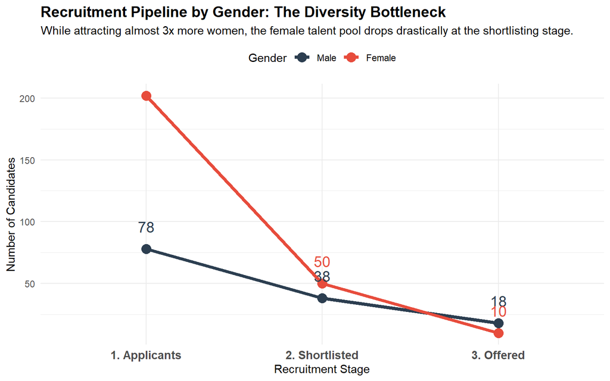

```r
# 0. Asegúrate de tener las librerías necesarias
library(tidyverse)

# 1. Preparar los datos del pipeline
pipeline_gender <- df2 %>%
  group_by(Gender) %>%
  summarise(
    `1. Applicants` = n(),
    `2. Shortlisted` = sum(ShortlistedNY == "Shortlisted", na.rm = TRUE),
    `3. Offered` = sum(OfferNY == "Made Offer", na.rm = TRUE)
  ) %>%
  pivot_longer(cols = -Gender, names_to = "Stage", values_to = "Count")

# 2. Crear el gráfico
ggplot(pipeline_gender, aes(x = Stage, y = Count, group = Gender, color = Gender)) +
  geom_line(linewidth = 1.5) +
  geom_point(size = 4) +
  geom_text(aes(label = Count), vjust = -1.5, size = 5, show.legend = FALSE) +
  scale_color_manual(values = c("Male" = "#2c3e50", "Female" = "#e74c3c")) +
  theme_minimal() +
  labs(
    title = "Recruitment Pipeline by Gender: The Diversity Bottleneck",
    subtitle = "While attracting almost 3x more women, the female talent pool drops drastically at the shortlisting stage.",
    x = "Recruitment Stage",
    y = "Number of Candidates",
    color = "Gender"
  ) +
  theme(
    plot.title = element_text(face = "bold", size = 14),
    axis.text.x = element_text(size = 11, face = "bold"),
    legend.position = "top"
  )
```

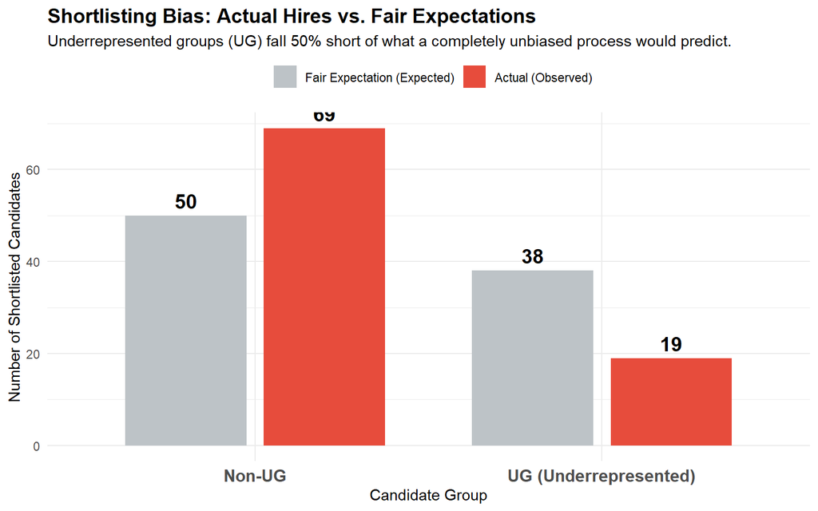

```r
# 1. Extraer los datos exactos de la prueba Chi-cuadrado que ya hiciste
test_chi_ug <- chisq.test(table(df2$UGyn, df2$ShortlistedNY))

# 2. Construir un dataframe resumen para el gráfico
df_obs_exp_ug <- data.frame(
  Group = c("UG (Underrepresented)", "UG (Underrepresented)", "Non-UG", "Non-UG"),
  Metric = factor(c("Actual (Observed)", "Fair Expectation (Expected)",
                    "Actual (Observed)", "Fair Expectation (Expected)"),
                  levels = c("Fair Expectation (Expected)", "Actual (Observed)")),
  Count = c(
    test_chi_ug$observed["Yes", "Shortlisted"],
    test_chi_ug$expected["Yes", "Shortlisted"],
    test_chi_ug$observed["No", "Shortlisted"],
    test_chi_ug$expected["No", "Shortlisted"]
  )
)

# 3. Crear el gráfico de barras agrupadas
ggplot(df_obs_exp_ug, aes(x = Group, y = Count, fill = Metric)) +
  geom_bar(stat = "identity", position = position_dodge(width = 0.8), width = 0.7) +
  geom_text(aes(label = round(Count, 0)),
            position = position_dodge(width = 0.8), vjust = -0.5, size = 5, fontface = "bold") +
  scale_fill_manual(values = c("Fair Expectation (Expected)" = "#bdc3c7", # Gris neutro
                               "Actual (Observed)" = "#e74c3c")) +         # Rojo alerta
  theme_minimal() +
  labs(
    title = "Shortlisting Bias: Actual Hires vs. Fair Expectations",
    subtitle = "Underrepresented groups (UG) fall 50% short of what a completely unbiased process would predict.",
    x = "Candidate Group",
    y = "Number of Shortlisted Candidates",
    fill = ""
  ) +
  theme(
    plot.title = element_text(face = "bold", size = 14),
    axis.text.x = element_text(size = 12, face = "bold"),
    legend.position = "top"
  )
```

# Prompt 3: Predicting Shortlisting Using Demographics

### Tasks

- Import ‘recruitment_applicants_2023.xlsx’ into R (definitions of all fields are included in the ‘variable key’ worksheet within the Excel file).
- Run logistic regression with Gender and UG as predictors and ShortlistedNY as target.
- Interpret odds ratios and model fit (Nagelkerke R²).
- Comment on potential compound bias (e.g., female & UG status).

### Deliverables

- Model output.
- Odds ratios and statistical significance.
- Recommendations to improve fairness in shortlisting.

## Solution

### Model output

```r
# Cargar la librería necesaria para calcular el Nagelkerke R²
if(!require(DescTools)) install.packages("DescTools")
library(DescTools)

# Para la regresión logística, es más seguro usar una variable objetivo numérica (0 y 1).
# Convertimos 'ShortlistedNY' (1 = Shortlisted, 0 = Rejected).
df2$Shortlisted_num <- ifelse(df2$ShortlistedNY == "Shortlisted", 1, 0)

# Ajustar el modelo de regresión logística con Gender y UGyn como predictores
model_shortlist <- glm(Shortlisted_num ~ Gender + UGyn,
                       data = df2,
                       family = binomial)

# Imprimir el resumen del modelo para ver los coeficientes y los p-valores (significancia estadística)
summary(model_shortlist)
```

```
##
## Call:
## glm(formula = Shortlisted_num ~ Gender + UGyn, family = binomial,
##     data = df2)
##
## Coefficients:
##              Estimate Std. Error z value Pr(>|z|)
## (Intercept)   -0.9232     0.3042  -3.035  0.00241 **
## GenderFemale  -1.1957     0.3006  -3.978 6.94e-05 ***
## UGynNo         1.5157     0.3096   4.895 9.83e-07 ***
## ---
## Signif. codes:  0 '***' 0.001 '**' 0.01 '*' 0.05 '.' 0.1 ' ' 1
##
## (Dispersion parameter for binomial family taken to be 1)
##
##     Null deviance: 348.59  on 279  degrees of freedom
## Residual deviance: 306.61  on 277  degrees of freedom
## AIC: 312.61
##
## Number of Fisher Scoring iterations: 4
```

```r
# Calcular y mostrar el ajuste del modelo (Nagelkerke R²)
cat("\n--- Model Fit (Nagelkerke R²) ---\n")
```

```
##
## --- Model Fit (Nagelkerke R²) ---
```

```r
PseudoR2(model_shortlist, which = "Nagelkerke")
```

```
## Nagelkerke
##  0.1955351
```

### Odds ratios and statistical significance

```r
# Calcular los Odds Ratios exponencializando los coeficientes del modelo
cat("\n--- Odds Ratios ---\n")
```

```
##
## --- Odds Ratios ---
```

```r
odds_ratios <- exp(coef(model_shortlist))
print(odds_ratios)
```

```
##  (Intercept) GenderFemale       UGynNo
##    0.3972580    0.3025043    4.5525019
```

```r
# Calcular los intervalos de confianza al 95% para los Odds Ratios
cat("\n--- 95% Confidence Intervals for Odds Ratios ---\n")
```

```
##
## --- 95% Confidence Intervals for Odds Ratios ---
```

```r
conf_intervals <- exp(confint(model_shortlist))
print(conf_intervals)
```

```
##                  2.5 %    97.5 %
## (Intercept)  0.2140377 0.7097995
## GenderFemale 0.1663094 0.5422660
## UGynNo       2.5282087 8.5525992
```

### Recommendations to improve fairness in shortlisting

Both gender and underrepresented group status are highly significant predictors in the shortlisting model, as their p-values are well below 0.05. This provides strong statistical evidence that the initial screening process is not demographically neutral.

The model yields a Nagelkerke $R^{2}$ of 19.55%. While a 19.55% explanatory power might seem relatively low in some statistical contexts, in People Analytics and specifically when evaluating recruitment fairness, this is a very substantial and concerning figure. It indicates that nearly one-fifth of the variance in shortlisting decisions is driven solely by a candidate’s gender and UG status, rather than their actual skills or merit.

- **Gender Disadvantage:** the negative coefficient for female candidates (-1.19) translates to an odds ratio of approximately 0.30. This means that, holding other factors constant, women have 70% lower odds of being shortlisted compared to men. The data clearly shows that being a woman in this specific selection process is a major disadvantage.
- **UG Status Advantage for the Majority:** Not belonging to an underrepresented group yields a large positive coefficient (+1.51), which translates to an odds ratio of approximately 4.55. This indicates that majority candidates (Non-UG) have 4.5 times higher odds of passing the screening phase compared to candidates from underrepresented groups.

**Conclusion & Recommendations**

The model reveals a severe systemic bias in the shortlisting phase. Furthermore, the combination of these factors points to a severe compound bias: a candidate who is both female and belongs to an underrepresented group faces a multiplicative penalty, making her chances of being shortlisted statistically minimal compared to a non-UG male candidate. To mitigate this, the organization should strongly consider implementing blind CV screening and structured evaluation rubrics for the initial stages of recruitment.

# Prompt 4: Validating Selection Tools Using Performance Ratings

### Tasks

- Import ‘selection.xlsx’ into R (definitions of all fields are included in the ‘variable key’ worksheet within the Excel file).
- Predict Year 1 performance rating using demographic, personality, competency, aptitude, and onboarding variables.
- Use linear regression with standardized coefficients.
- Interpret model fit and variable importance.

### Deliverables

- Regression summary with top predictors.
- Evaluation of selection validity: Which tools truly predict performance?

## Solution

### Regression summary with top predictors

```r
library(readxl)
library(dplyr)
library(lm.beta)
library(broom)
library(car)
# Import data
selection <- read_excel("Databases/selection.xlsx", sheet = "data")

# Keep only observations with Year 1 performance available
selection_model <- selection %>%
  filter(!is.na(Year1performanceRating))

# Linear regression
# Omit HRDummyV so HR becomes the reference category
model_p4 <- lm(
  Year1performanceRating ~
    Gender + EducationHighest + UGYN + WorkExperience +
    ACPersonalityO + ACPersonalityC + ACPersonalityE + ACPersonalityA + ACPersonalityN +
    ACRatingINTCOMPA + ACRatingINTCOMPB + ACRatingINTCOMPC +
    ACRatingINTCOMPD + ACRatingINTCOMPE +
    ACRatingAPTnumerical + ACRatingAPTverbal +
    InductionDay + InductionWeek + OnBoardingBuddy +
    FinanceDummyV + MarketingDummyV + SalesDummyV +
    RiskDummyV + LegalDummyV + OperationsDummyV,
  data = selection_model
)

# Standardized coefficients
model_p4_beta <- lm.beta(model_p4)

# Full summary
summary(model_p4_beta)
```

```
##
## Call:
## lm(formula = Year1performanceRating ~ Gender + EducationHighest +
##     UGYN + WorkExperience + ACPersonalityO + ACPersonalityC +
##     ACPersonalityE + ACPersonalityA + ACPersonalityN + ACRatingINTCOMPA +
##     ACRatingINTCOMPB + ACRatingINTCOMPC + ACRatingINTCOMPD +
##     ACRatingINTCOMPE + ACRatingAPTnumerical + ACRatingAPTverbal +
##     InductionDay + InductionWeek + OnBoardingBuddy + FinanceDummyV +
##     MarketingDummyV + SalesDummyV + RiskDummyV + LegalDummyV +
##     OperationsDummyV, data = selection_model)
##
## Residuals:
##      Min       1Q   Median       3Q      Max
## -2.05797 -0.30754  0.00088  0.41912  1.62688
##
## Coefficients:
##                        Estimate Standardized Std. Error t value Pr(>|t|)
## (Intercept)          -4.8225077           NA  1.2015570  -4.014 7.61e-05 ***
## Gender               -0.8578881   -0.3620788  0.1306267  -6.567 2.34e-10 ***
## EducationHighest      0.1384466    0.0637305  0.0825704   1.677 0.094669 .
## UGYN                 -0.0193234   -0.0067813  0.1039189  -0.186 0.852616
## WorkExperience        0.0606132    0.0244825  0.0892045   0.679 0.497368
## ACPersonalityO       -0.0034899   -0.0448255  0.0037530  -0.930 0.353190
## ACPersonalityC        0.0079011    0.1436669  0.0026536   2.978 0.003149 **
## ACPersonalityE        0.0097542    0.1790423  0.0035029   2.785 0.005710 **
## ACPersonalityA        0.0009825    0.0183123  0.0030945   0.317 0.751104
## ACPersonalityN       -0.0009245   -0.0159994  0.0022080  -0.419 0.675739
## ACRatingINTCOMPA      0.3638584    0.1551446  0.1381901   2.633 0.008913 **
## ACRatingINTCOMPB      0.1306136    0.0463419  0.1197009   1.091 0.276099
## ACRatingINTCOMPC      0.0903146    0.0323813  0.1402235   0.644 0.520032
## ACRatingINTCOMPD      0.3592834    0.1496589  0.1125143   3.193 0.001561 **
## ACRatingINTCOMPE      0.3456275    0.1226291  0.1654996   2.088 0.037629 *
## ACRatingAPTnumerical  0.0099152    0.0698604  0.0070480   1.407 0.160550
## ACRatingAPTverbal     0.0077312    0.0394475  0.0100409   0.770 0.441940
## InductionDay          0.3567033    0.1023576  0.1412323   2.526 0.012078 *
## InductionWeek         0.0234061    0.0073125  0.1286484   0.182 0.855757
## OnBoardingBuddy       0.2318439    0.0350132  0.2521455   0.919 0.358601
## FinanceDummyV         0.1540589    0.0507800  0.2537409   0.607 0.544223
## MarketingDummyV       0.6236678    0.2236088  0.2194201   2.842 0.004794 **
## SalesDummyV          -0.0636855   -0.0156164  0.2959641  -0.215 0.829777
## RiskDummyV            0.9228754    0.2188174  0.2446009   3.773 0.000195 ***
## LegalDummyV           1.1510105    0.3565681  0.2548264   4.517 9.12e-06 ***
## OperationsDummyV      0.4018696    0.1153183  0.2333447   1.722 0.086090 .
## ---
## Signif. codes:  0 '***' 0.001 '**' 0.01 '*' 0.05 '.' 0.1 ' ' 1
##
## Residual standard error: 0.6991 on 292 degrees of freedom
## Multiple R-squared:  0.6639, Adjusted R-squared:  0.6352
## F-statistic: 23.08 on 25 and 292 DF,  p-value: < 2.2e-16
```

```r
# Tidy table with standardized coefficients
p4_results <- broom::tidy(model_p4_beta) %>%
  mutate(std_beta = c(NA, lm.beta(model_p4)$standardized.coefficients[-1])) %>%
  arrange(desc(abs(std_beta)))

p4_results
```

```
## # A tibble: 26 × 7
##    term             estimate std_estimate std.error statistic  p.value std_beta
##    <chr>               <dbl>        <dbl>     <dbl>     <dbl>    <dbl>    <dbl>
##  1 Gender           -0.858         -0.362   0.131       -6.57 2.34e-10   -0.362
##  2 LegalDummyV       1.15           0.357   0.255        4.52 9.12e- 6    0.357
##  3 MarketingDummyV   0.624          0.224   0.219        2.84 4.79e- 3    0.224
##  4 RiskDummyV        0.923          0.219   0.245        3.77 1.95e- 4    0.219
##  5 ACPersonalityE    0.00975        0.179   0.00350      2.78 5.71e- 3    0.179
##  6 ACRatingINTCOMPA  0.364          0.155   0.138        2.63 8.91e- 3    0.155
##  7 ACRatingINTCOMPD  0.359          0.150   0.113        3.19 1.56e- 3    0.150
##  8 ACPersonalityC    0.00790        0.144   0.00265      2.98 3.15e- 3    0.144
##  9 ACRatingINTCOMPE  0.346          0.123   0.165        2.09 3.76e- 2    0.123
## 10 OperationsDummyV  0.402          0.115   0.233        1.72 8.61e- 2    0.115
## # ℹ 16 more rows
```

```r
# Optional: multicollinearity check
car::vif(model_p4)
```

```
##               Gender     EducationHighest                 UGYN
##             2.641014             1.255280             1.155625
##       WorkExperience       ACPersonalityO       ACPersonalityC
##             1.128005             2.019003             2.022807
##       ACPersonalityE       ACPersonalityA       ACPersonalityN
##             3.592152             2.890722             1.268680
##     ACRatingINTCOMPA     ACRatingINTCOMPB     ACRatingINTCOMPC
##             3.016643             1.567208             2.196214
##     ACRatingINTCOMPD     ACRatingINTCOMPE ACRatingAPTnumerical
##             1.908568             2.995891             2.142692
##    ACRatingAPTverbal         InductionDay        InductionWeek
##             2.280609             1.427105             1.403590
##      OnBoardingBuddy        FinanceDummyV      MarketingDummyV
##             1.259901             6.077900             5.377566
##          SalesDummyV           RiskDummyV          LegalDummyV
##             4.576328             2.922506             5.414732
##     OperationsDummyV
##             3.895686
```

**Leyend:** *ACRatingINTCOMPA = Assessment Centre Competency, Technical ACRatingINTCOMPB = Assessment Centre Competency, Team Player ACRatingINTCOMPC = Assessment Centre Competency Critical Thought ACRatingINTCOMPD = Assessment Centre Competency Business Aware, ACRatingINTCOMPE = Assessment Centre Competency Drive Innovation*

A multiple linear regression was conducted to predict **Year 1 performance rating** from demographic variables, personality measures, assessment-centre competency ratings, aptitude test scores, onboarding variables, and job-function controls. The overall model was statistically significant, **F(25, 292) = 23.08, p < .001**, indicating that the predictors jointly explained a meaningful proportion of variance in performance outcomes. The model showed strong explanatory power, with **R² = 0.664** and **adjusted R² = 0.635**, meaning that around 64% of the variance in Year 1 performance ratings was accounted for by the included variables.

Examining the standardized coefficients, the strongest significant predictors in the full model were **Gender** (β = -0.362, p < .001), **Legal job function** (β = 0.357, p < .001), **Marketing job function** (β = 0.224, p = .005), **Risk job function** (β = 0.219, p < .001), **Assessment Centre Personality Extraversion** (β = 0.179, p = .006), **Assessment Centre Competency Technical** (β = 0.155, p = .009), **Assessment Centre Competency Business Aware** (β = 0.150, p = .002), **Assessment Centre Personality Conscientious** (β = 0.144, p = .003), **Assessment Centre Competency Drive Innovation** (β = 0.123, p = .038), and **Attend Induction Day** (β = 0.102, p = .012). In contrast, **UG status**, **work experience**, **Openness**, **Agreeableness**, **Neuroticism**, **Team Player**, **Critical Thought**, **Numerical Aptitude Test Score**, **Verbal Reasoning Aptitude Test Score**, **Induction Week**, and **OnBoardingBuddy** were not statistically significant predictors in the full model.

### Evaluation of selection validity: Which tools truly predict performance?

To answer the validity question properly, it is important to distinguish between **contextual control variables** and actual **selection tools**. Although **Gender** and several **job-function dummies** were among the strongest predictors in the model, these variables do not represent selection methods themselves. Instead, they indicate that performance ratings vary across demographic coding and business areas, so they should be interpreted as contextual influences rather than evidence of selection validity.

Focusing specifically on the selection-related measures, the clearest evidence of predictive validity comes from selected **personality** and **competency** indicators. In particular, **Extraversion** and **Conscientiousness** were both positive and significant predictors of Year 1 performance, suggesting that these traits are meaningfully associated with stronger early job outcomes. In addition, the competency ratings for **Technical**, **Business Aware**, and **Drive Innovation** all made significant positive contributions, indicating that these assessment-centre dimensions successfully capture capabilities linked to later performance. Among onboarding measures, only **Attend Induction Day** showed a significant effect, while **Induction Week** and **OnBoardingBuddy** did not.

Overall, the findings suggest that the organization’s selection system is **partially valid rather than uniformly valid**. Some tools clearly contribute to predicting future performance, especially selected personality dimensions and specific competency ratings. However, other measures appear to add little incremental value once the full model is taken into account. Most notably, the **numerical** and **verbal aptitude tests** were not significant predictors in this analysis, nor were the competency dimensions **Team Player** and **Critical Thought**. This implies that the organization should place greater emphasis on the measures that demonstrate clear predictive value, while critically reviewing whether weaker tools meaningfully improve hiring decisions. In short, the results support the validity of parts of the assessment process, but they do not justify treating the entire assessment battery as equally effective.

# Prompt 5: Predicting Early Turnover

### Tasks

- Import ‘selection.xlsx’ into R (definitions of all fields are included in the ‘variable key’ worksheet within the Excel file).
- Run logistic regression to predict LeaverYr2.
- Use demographics, assessments, onboarding, and performance rating.
- Evaluate odds ratios and risk factors.

### Deliverables

- Model output and interpretation.
- Recommendations for reducing graduate attrition.

## Solution

### Model output and interpretation

```r
library(readxl)
library(dplyr)
library(broom)

# Import data
selection <- read_excel("databases/selection.xlsx", sheet = "data")

# Keep complete cases for the variables used in the model
selection_model <- selection %>%
  filter(!is.na(LeaverYr2),
         !is.na(Year1performanceRating))

# Logistic regression
# HR is omitted as the reference job function
model_p5 <- glm(
  LeaverYr2 ~
    Gender + EducationHighest + UGYN + WorkExperience +
    ACPersonalityO + ACPersonalityC + ACPersonalityE + ACPersonalityA + ACPersonalityN +
    ACRatingINTCOMPA + ACRatingINTCOMPB + ACRatingINTCOMPC +
    ACRatingINTCOMPD + ACRatingINTCOMPE +
    ACRatingAPTnumerical + ACRatingAPTverbal +
    InductionDay + InductionWeek + OnBoardingBuddy +
    FinanceDummyV + MarketingDummyV + SalesDummyV +
    RiskDummyV + LegalDummyV + OperationsDummyV +
    Year1performanceRating,
  data = selection_model,
  family = binomial(link = "logit")
)

summary(model_p5)
```

```
##
## Call:
## glm(formula = LeaverYr2 ~ Gender + EducationHighest + UGYN +
##     WorkExperience + ACPersonalityO + ACPersonalityC + ACPersonalityE +
##     ACPersonalityA + ACPersonalityN + ACRatingINTCOMPA + ACRatingINTCOMPB +
##     ACRatingINTCOMPC + ACRatingINTCOMPD + ACRatingINTCOMPE +
##     ACRatingAPTnumerical + ACRatingAPTverbal + InductionDay +
##     InductionWeek + OnBoardingBuddy + FinanceDummyV + MarketingDummyV +
##     SalesDummyV + RiskDummyV + LegalDummyV + OperationsDummyV +
##     Year1performanceRating, family = binomial(link = "logit"),
##     data = selection_model)
##
## Coefficients:
##                         Estimate Std. Error z value Pr(>|z|)
## (Intercept)             0.950507   5.340955   0.178 0.858750
## Gender                  1.475599   0.591895   2.493 0.012667 *
## EducationHighest       -0.061308   0.356463  -0.172 0.863446
## UGYN                    0.117642   0.436138   0.270 0.787363
## WorkExperience         -0.076379   0.357292  -0.214 0.830725
## ACPersonalityO         -0.022576   0.016252  -1.389 0.164796
## ACPersonalityC         -0.008892   0.011291  -0.788 0.430971
## ACPersonalityE          0.017251   0.014956   1.153 0.248744
## ACPersonalityA          0.001325   0.013808   0.096 0.923532
## ACPersonalityN          0.020552   0.009650   2.130 0.033196 *
## ACRatingINTCOMPA       -0.500084   0.563797  -0.887 0.375083
## ACRatingINTCOMPB        0.129340   0.480134   0.269 0.787634
## ACRatingINTCOMPC       -0.325908   0.558909  -0.583 0.559816
## ACRatingINTCOMPD       -0.496656   0.457434  -1.086 0.277593
## ACRatingINTCOMPE        0.437630   0.692689   0.632 0.527528
## ACRatingAPTnumerical   -0.060629   0.036303  -1.670 0.094906 .
## ACRatingAPTverbal       0.039984   0.043247   0.925 0.355199
## InductionDay           -1.969398   0.568591  -3.464 0.000533 ***
## InductionWeek           0.053869   0.510772   0.105 0.916006
## OnBoardingBuddy        -0.531975   1.086876  -0.489 0.624521
## FinanceDummyV           3.269841   1.249043   2.618 0.008848 **
## MarketingDummyV         2.895243   0.996511   2.905 0.003668 **
## SalesDummyV             2.634177   1.353398   1.946 0.051614 .
## RiskDummyV              2.862721   1.132839   2.527 0.011503 *
## LegalDummyV             1.695610   1.197348   1.416 0.156735
## OperationsDummyV        2.766293   1.081260   2.558 0.010516 *
## Year1performanceRating  0.086310   0.241503   0.357 0.720802
## ---
## Signif. codes:  0 '***' 0.001 '**' 0.01 '*' 0.05 '.' 0.1 ' ' 1
##
## (Dispersion parameter for binomial family taken to be 1)
##
##     Null deviance: 380.76  on 317  degrees of freedom
## Residual deviance: 263.62  on 291  degrees of freedom
## AIC: 317.62
##
## Number of Fisher Scoring iterations: 5
```

```r
# Odds ratios with 95% CI
p5_results <- broom::tidy(model_p5, conf.int = TRUE, exponentiate = TRUE) %>%
  arrange(p.value)

p5_results
```

```
## # A tibble: 27 × 7
##    term                 estimate std.error statistic  p.value conf.low conf.high
##    <chr>                   <dbl>     <dbl>     <dbl>    <dbl>    <dbl>     <dbl>
##  1 InductionDay            0.140   0.569       -3.46 0.000533   0.0433     0.409
##  2 MarketingDummyV        18.1     0.997        2.91 0.00367    2.76     140.
##  3 FinanceDummyV          26.3     1.25         2.62 0.00885    2.56     354.
##  4 OperationsDummyV       15.9     1.08         2.56 0.0105     2.04     145.
##  5 RiskDummyV             17.5     1.13         2.53 0.0115     2.14     193.
##  6 Gender                  4.37    0.592        2.49 0.0127     1.41      14.6
##  7 ACPersonalityN          1.02    0.00965      2.13 0.0332     1.00       1.04
##  8 SalesDummyV            13.9     1.35         1.95 0.0516     1.05     218.
##  9 ACRatingAPTnumerical    0.941   0.0363      -1.67 0.0949     0.875      1.01
## 10 LegalDummyV             5.45    1.20         1.42 0.157      0.539     60.1
## # ℹ 17 more rows
```

A binary logistic regression was conducted to predict LeaverYr2 using demographic variables, assessment-centre measures, aptitude scores, onboarding variables, job-function controls, and Year 1 performance rating. The model fit the data significantly better than the null model, as shown by the substantial reduction in deviance from 380.76 to 263.62, indicating that the predictors jointly provide meaningful information about early turnover. Based on the deviance reduction, the model explains approximately 31% of the variation in turnover risk, which represents a reasonably strong result for an HR attrition model.

The strongest predictor in the model was Attend Induction Day, which was associated with substantially lower odds of leaving by Year 2 (OR = 0.14, 95% CI [0.04, 0.41], p < .001). This indicates that employees who attended Induction Day had approximately 86% lower odds of early turnover, holding the other variables constant. Significant positive risk factors included Gender (OR = 4.37, p = .013), Assessment Centre Personality Neuroticism (OR = 1.02, p = .033), and several job-function controls, particularly Finance, Marketing, Risk, and Operations, all of which showed substantially higher odds of turnover relative to the omitted reference function. However, these job-function effects should be interpreted cautiously because their confidence intervals are wide, indicating uncertainty around the precise magnitude of the effect.

Importantly, Year 1 performance rating was not a significant predictor of leaving by Year 2 (OR = 1.09, p = .721). Most assessment-centre competency variables were also non-significant, as were UG status, education level, work experience, verbal aptitude, Induction Week, and OnBoardingBuddy. Overall, these findings suggest that early turnover in this sample is not primarily explained by lower first-year performance, but instead appears more closely related to onboarding participation, personality-related vulnerability, and structural differences across job functions.

### Recommendations for reducing graduate attrition

The most immediate recommendation is to strengthen and monitor Induction Day participation, since it was the clearest protective factor in the model. If attendance is inconsistent, optional, or unevenly implemented across functions, the organization should review this urgently. The size of the observed association suggests that early integration may play an important role in whether graduates remain with the firm.

Second, the company should investigate why turnover risk is markedly higher in Finance, Marketing, Risk, and Operations than in the reference function. Since Year 1 performance rating was not significant, these differences do not appear to be explained simply by weaker employees leaving. HR should therefore examine role demands, manager support, workload, expectations, and early career experience within those business areas.

Third, the significant association between Gender and attrition suggests the need for a closer review of whether some groups experience the graduate journey differently. This should not be treated as proof of causality, but it is strong enough to justify follow-up analysis of support, inclusion, progression opportunities, and work climate. Finally, because Neuroticism was positively associated with leaving risk, the organization may benefit from strengthening resilience-building, check-ins, and tailored support during the early employment period. Overall, the most effective retention strategy is likely to focus on onboarding quality and function-specific experience, rather than assuming that early leavers are simply poor performers.